# Tarea 4

Federico Rebolledo 135700; Santin Gallardo 135936

# Tipos de Cambio MXN-USD de 2006 a 2014

La información se obtuvo de la página del Banco de México el día 28 de agosto de 2014.

```r
directorio<-"C:\\Users\\Federico\\Documents\\R Markdown\\Tarea4"
setwd(directorio)
TC.Banxico<-read.table("./tipoCambioBanxico.txt",
                       sep = "|",
                       header = TRUE,
                       stringsAsFactors = FALSE)
```

```r
TC.Banxico$Fecha.DOF<-as.Date(TC.Banxico$Fecha.DOF,
                             format = "%d/%m/%Y")
temporal<-as.POSIXlt(TC.Banxico$Fecha.DOF)
TC.Banxico$año<-unclass(temporal)$year+1900
```

```r
TC.Banxico.existentes<-subset(TC.Banxico, TC !="N/E")
TC.Banxico.existentes$TC<-as.numeric(TC.Banxico.existentes$TC)
str(TC.Banxico.existentes)
```

```
## 'data.frame':    2177 obs. of  3 variables:
##  $ Fecha.DOF: Date, format: "2006-01-02" "2006-01-03" ...
##  $ TC       : num  10.6 10.6 10.6 10.6 10.6 ...
##  $ año      : num  2006 2006 2006 2006 2006 ...
```

### Histogramas

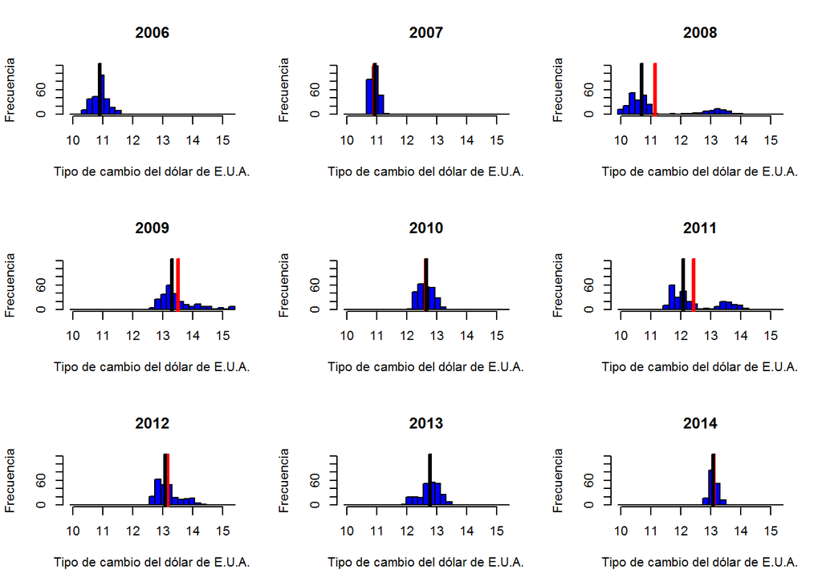

```r
par(mfrow = c(3, 3))
for(i in 2006:2014){
  tc<-subset(TC.Banxico.existentes, año==i)
  hist(tc$TC,
       col = "blue",
       breaks = seq(9.9, 15.4, length.out = 30),
       xlim = c(9.9,15.4),
       ylim = c(0, 120),
       ylab="Frecuencia",
       xlab="Tipo de cambio del dólar de E.U.A.",
       main=i)
  media<-mean(tc$TC, na.rm=TRUE)
  mediana<-median(tc$TC, na.rm=TRUE)
  abline(v = media, col = "red", lwd=3)
  abline(v = mediana, col = "black", lwd=3)
}
```

Los dos primeros años el tipo de cambio se mantuvo alrededor de los once pesos. En 2008 con la crisis se observa una alta varianza en los datos alcanzando tipos de cambio cercanos a los $14. Los dos siguientes años fueron periodos de recesión y recuperación, volviendo a un tipo de cambio más estable hasta 2010. Pero en 2011 con los cambios en los precios de petróleo se volvieron a observar fuertes variaciones en los tipos de cambio generando que la media pasara a colocarse alrededor de los $13 para los tres años siguientes observándose la mayor estabilidad en 2014.